# Analyse Descriptive

```r
data=read.csv("../Data/socsupport.csv",header=TRUE,sep=";")
attach(data)
str(data)
```

```
## 'data.frame':    95 obs. of  21 variables:
##  $ X           : int  1 2 3 4 5 6 7 8 9 10 ...
##  $ gender      : Factor w/ 2 levels "female","male": 2 1 2 2 1 1 1 1 1 2 ...
##  $ age         : Factor w/ 5 levels "18-20","21-24",..: 2 2 2 1 2 2 3 3 1 5 ...
##  $ country     : Factor w/ 2 levels "australia","other": 1 1 1 1 1 1 1 1 1 1 ...
##  $ marital     : Factor w/ 3 levels "married","other",..: 2 3 3 3 3 3 1 1 3 2 ...
##  $ livewith    : Factor w/ 6 levels "alone","friends",..: 5 5 6 4 2 2 5 5 4 1 ...
##  $ employment  : Factor w/ 5 levels "employed fulltime",..: 2 5 2 2 2 3 2 2 2 2 ...
##  $ firstyr     : Factor w/ 2 levels "first year","other": 2 2 2 1 2 2 2 2 2 2 ...
##  $ enrolment   : Factor w/ 3 levels "","full-time",..: 2 2 2 2 2 2 2 3 2 2 ...
##  $ emotional   : int  22 21 21 19 16 20 20 20 24 13 ...
##  $ emotionalsat: int  23 20 18 19 19 17 23 20 25 18 ...
##  $ tangible    : int  17 12 16 20 11 16 20 16 20 6 ...
##  $ tangiblesat : int  18 10 16 17 15 15 20 16 20 14 ...
##  $ affect      : int  15 10 15 11 6 12 14 12 15 6 ...
##  $ affectsat   : int  15 6 15 11 10 14 15 12 15 12 ...
##  $ psi         : int  12 9 13 13 11 12 15 12 12 6 ...
##  $ psisat      : int  13 6 12 12 12 11 15 12 15 11 ...
##  $ esupport    : int  13 12 14 15 9 13 15 13 16 10 ...
##  $ psupport    : int  11 7 13 15 7 12 10 11 NA 8 ...
##  $ supsources  : int  13 10 14 15 9 13 13 11 NA 9 ...
##  $ BDI         : int  5 8 16 0 9 0 1 14 12 20 ...
```

On trouve 8 variables qualitatives et 13 variables quantitatives. Les données sont chargées correctement aux vues des descriptions du jeu de données (la 13ième variable quantitative correspond à un indice lié à chaque individu et n’est pas utile à notre étude). On remarque cependant que certaines données au niveau des variables quantitatives sont incomplètes. On supprime donc les individus correspondant pour ne pas avoir de problèmes plus tard (nous les supprimerons pour toutes les études des variables quantitatives).

```r
n=nrow(data)
p=ncol(data)

delete = vector("numeric",n)

for(i in 1:n){
  for(j in 1:p){
    if(is.na(data[i,j]))
      delete[i]=1
  }
}

for(i in n:1){
  if (delete[i]==1)
    data=data[-c(i),]
}

data = data[,-c(1)]

summary(data)
```

```
##     gender      age          country      marital         livewith
##  female:68   18-20:39   australia:80   married: 9   alone     : 2
##  male  :22   21-24:35   other    :10   other  :10   friends   : 7
##              25-30: 6                  single :71   other     : 3
##              31-40: 6                               parents   :38
##              40+  : 4                               partner   :21
##                                                     residences:19
##               employment       firstyr       enrolment    emotional
##  employed fulltime : 2   first year:21            : 4   Min.   : 6.0
##  employed part-time:43   other     :69   full-time:75   1st Qu.:18.0
##  govt assistance   :14                   part-time:11   Median :20.0
##  other             :13                                  Mean   :19.4
##  parental support  :18                                  3rd Qu.:21.0
##                                                         Max.   :25.0
##   emotionalsat      tangible      tangiblesat        affect
##  Min.   : 8.00   Min.   : 4.00   Min.   : 8.00   Min.   : 3.00
##  1st Qu.:19.00   1st Qu.:14.00   1st Qu.:15.25   1st Qu.:10.00
##  Median :20.00   Median :18.00   Median :17.50   Median :13.00
##  Mean   :19.92   Mean   :16.49   Mean   :16.94   Mean   :12.08
##  3rd Qu.:22.00   3rd Qu.:20.00   3rd Qu.:20.00   3rd Qu.:15.00
##  Max.   :25.00   Max.   :20.00   Max.   :20.00   Max.   :15.00
##    affectsat          psi            psisat         esupport
##  Min.   : 3.00   Min.   : 5.00   Min.   : 5.00   Min.   : 6.0
##  1st Qu.:11.00   1st Qu.:11.00   1st Qu.:11.25   1st Qu.:11.0
##  Median :13.00   Median :12.00   Median :12.00   Median :13.0
##  Mean   :12.37   Mean   :11.86   Mean   :12.20   Mean   :12.8
##  3rd Qu.:15.00   3rd Qu.:14.00   3rd Qu.:14.00   3rd Qu.:14.0
##  Max.   :15.00   Max.   :15.00   Max.   :15.00   Max.   :19.0
##     psupport       supsources         BDI
##  Min.   : 4.00   Min.   : 5.00   Min.   : 0.00
##  1st Qu.: 8.00   1st Qu.: 9.00   1st Qu.: 5.00
##  Median :10.00   Median :11.00   Median : 8.50
##  Mean   :10.43   Mean   :10.89   Mean   :10.86
##  3rd Qu.:12.75   3rd Qu.:13.00   3rd Qu.:14.00
##  Max.   :20.00   Max.   :16.00   Max.   :48.00
```

La table summary nous donne un grand nombre d’informations que ce soit sur les variables quantitatives ou sur les variables qualitatives. On peut observer la répartition des individus selon les variables qualitatives et des données statistiques concernant les variables quantitatives. Ces informations sont cependant difficile à lire à travers cette table. Pour faciliter la représentation, nous allons utiliser d’une part des boxplot pour les variables quantitatives et des diagrammes en “camembert” pour les variables qualitatives.

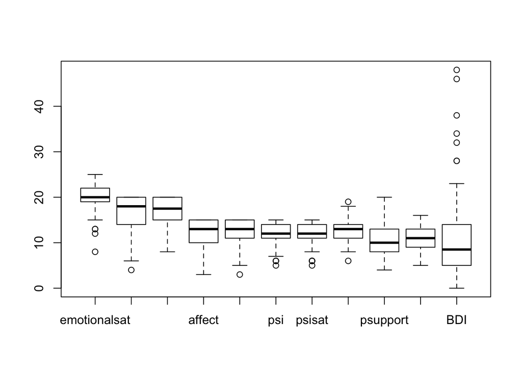

```r
boxplot(data[,-c(1,2,3,4,5,6,7,8,9)])
```

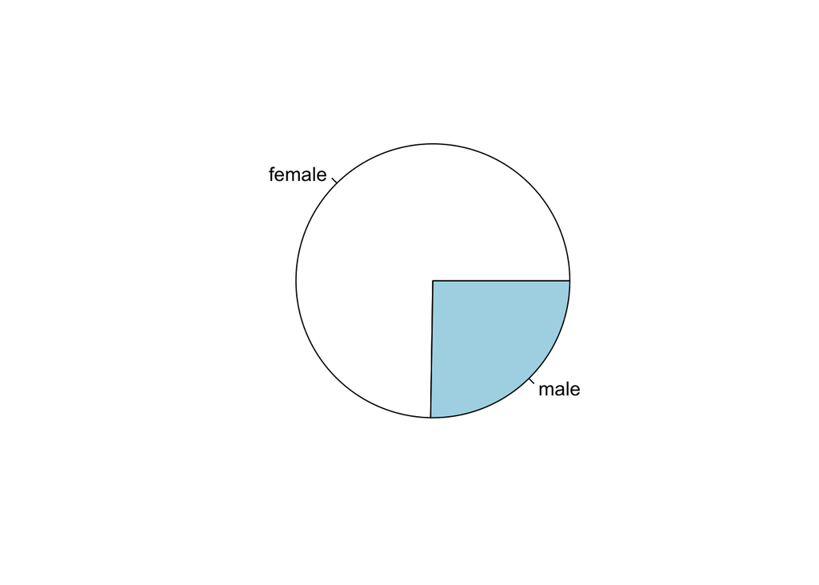

```r
pie(table(gender))
```

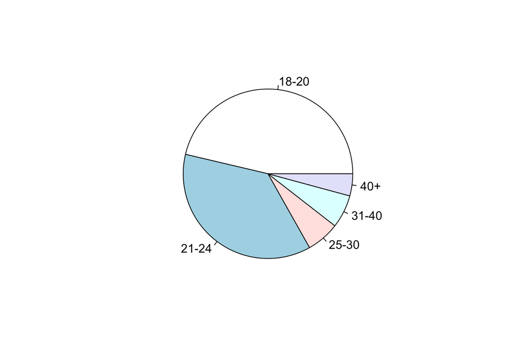

```r
pie(table(age))
```

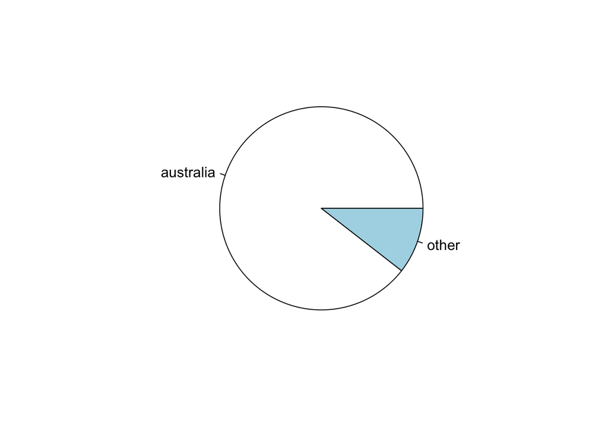

```r
pie(table(country))
```

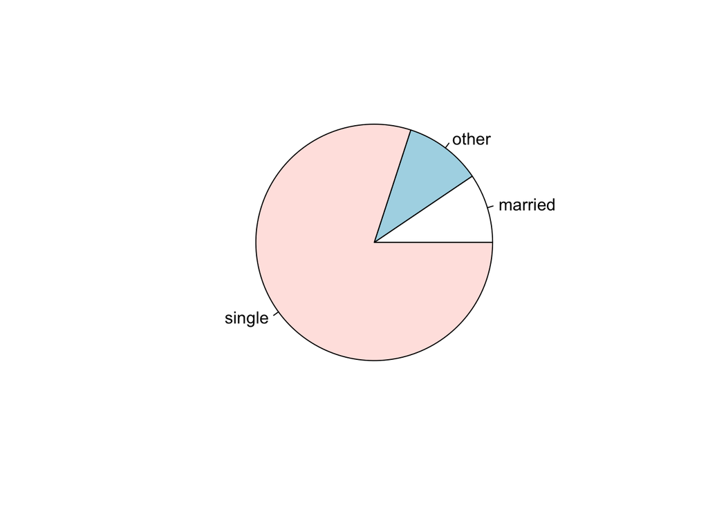

```r
pie(table(marital))
```

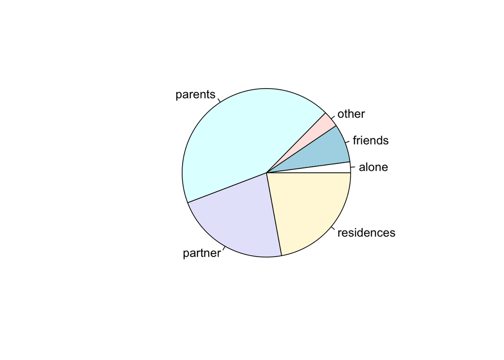

```r
pie(table(livewith))
```

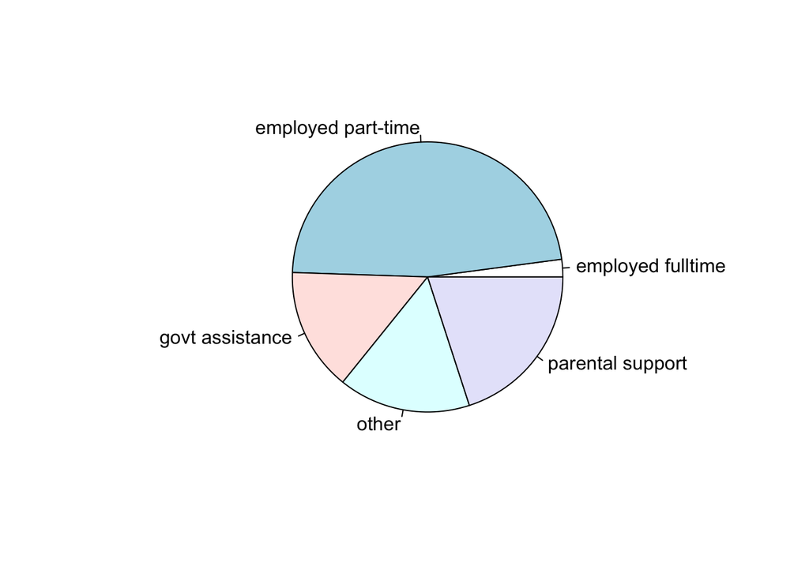

```r
pie(table(employment))
```

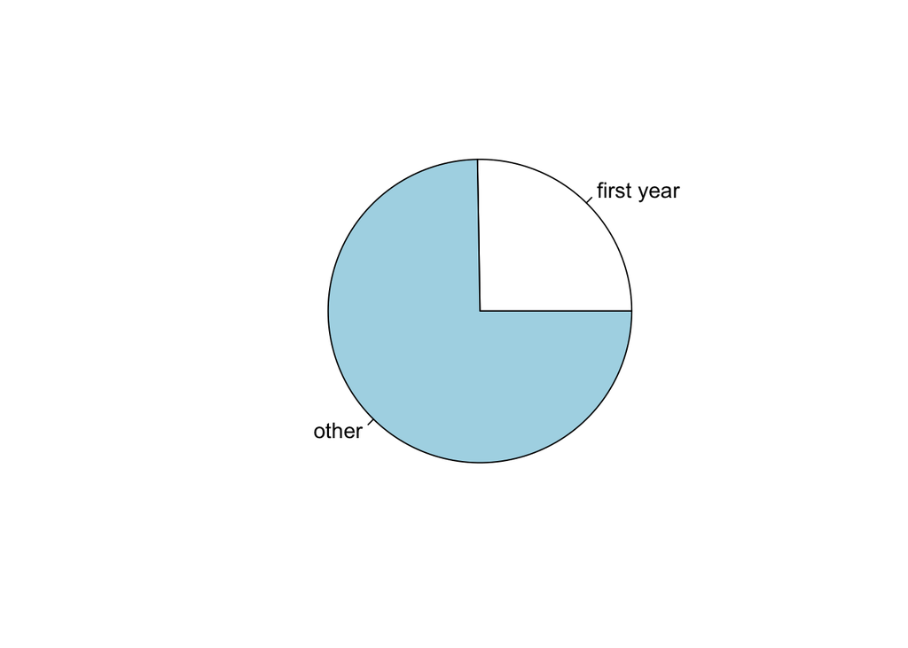

```r
pie(table(firstyr))
```

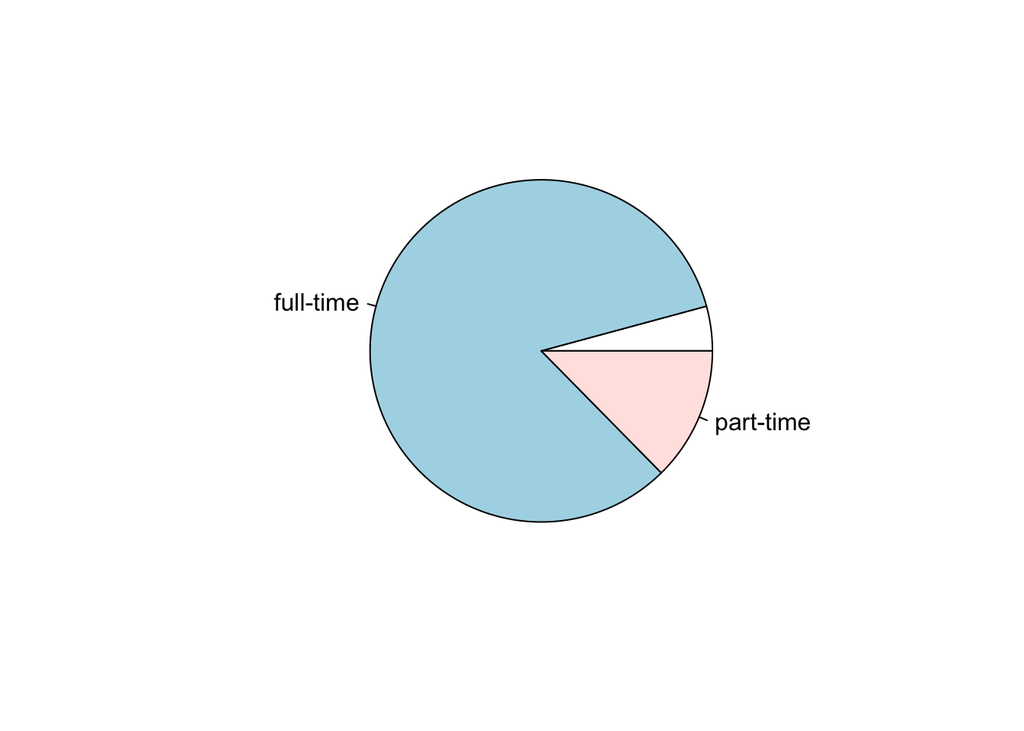

```r
pie(table(enrolment))
```

On remarque que certaines variables sont assez mal réparties, comme par exemple le nombre d’australiens qui est très supérieur aux autres au niveau de country. Nous verrons plus tard si ces variables ont vraiment un impact sur les autres éléments du jeu de données et si elles nous permettent tout de même d’extraire des informations.

[figure not shown]

```r
pairs(data)
```

Le tableau des corrélations 2 à 2 obtenus par pairs n’est pas sufffisamment lisible pour obtenir des informations sur le jeu de données. Nous allons donc poursuivre notre extraction d’information à l’aide de différentes méthodes plus appropriées.